# V3: Secondary Aims Analysis

Using moderators and Q-learning for more deeply-tailored AI

Authors

Mason Ferlic

Jamie Yap

John J. Dziak

Daniel Almirall

## 1 Learning Goals

Learn how to examine moderators of first and second-stage treatment effects

- Test moderator for significance
- Interaction plot to determine if moderator is useful tailoring variable

Learn how Q-learning works

- Implement using the R Package `qlaci`

## 2 Setup

Load required packages (these should be installed if you ran the setup script!)

```r
library(CATIE2023)
library(geepack)
library(tidyverse)
library(emmeans)
# devtools::install_github('d3lab-isr/qlaci')
```

## 3 Load data

This is data that was *simulated* to mimic data arising from the ADHD SMART study (PI: William Pelham). An accompanying handout (“ADHD Handout.pdf”) describes the variables in the data.

```r
# Load data
adhd <- CATIE2023::adhd
```

### Examine data

```r
head(adhd) %>%
    knitr::kable(digits = 2)
```

ADHD data.frame

| ID | odd | severity | priormed | race | Y0 | A1 | R | NRtime | adherence | Y1 | A2 | Y2 |
| --- | --- | --- | --- | --- | --- | --- | --- | --- | --- | --- | --- | --- |
| 1 | 1 | 2.88 | 0 | 1 | 2.32 | -1 | 0 | 4 | 0 | 2.79 | 1 | 0.60 |
| 2 | 0 | 4.13 | 0 | 0 | 2.07 | 1 | 1 | NA | 1 | 2.20 | NA | 4.27 |
| 3 | 1 | 5.57 | 0 | 1 | 1.00 | -1 | 1 | NA | 0 | 2.29 | NA | 1.45 |
| 4 | 0 | 4.93 | 0 | 1 | 3.23 | 1 | 0 | 4 | 0 | 3.05 | -1 | 6.76 |
| 5 | 1 | 5.50 | 0 | 1 | 1.48 | 1 | 0 | 6 | 0 | 1.73 | -1 | 3.58 |
| 6 | 0 | 5.50 | 0 | 1 | 1.72 | 1 | 0 | 3 | 0 | 2.40 | 1 | 2.07 |

### Clean data

Here we fill missing values and grand mean center the baseline covariates.

```r
# Fill NA's with zero (A2 and NRtime is undefined for Responders)
adhd[is.na(adhd)] <- 0

# Grand mean center all baseline covariates, append '_c' for centered
adhd_c <- adhd %>%
    mutate(across(c(odd, severity, priormed, race), ~.x - mean(.x), .names = "{.col}_c"))
```

## 4 Moderators of stage 1 main effect

We’ll start by fitting a **moderated regression model** to examine whether baseline variable `priormed` is a moderator of first-stage treatment $A_1$ on end-of study outcome $Y_2$ controlling for other baseline covariates $\mathbf{X}_c$ (mean centered). The model is as follows:

$$\begin{gather}
E[Y_2 \mid \mathbf{X}_c, \text{priormed}, A_1] = \beta_0 +
\eta^TX_c + \beta_1\text{priormed} +
\beta_2A_1 + \beta_3(A_1 \times \text{priormed})
\end{gather}$$

```r
# Fit a linear model to test if priormed moderates A1
mod1 <- geepack::geeglm(Y2 ~ odd_c + severity_c + race_c + priormed + A1 + priormed:A1,
    data = adhd_c, id = ID)

tidy(mod1) %>%
    knitr::kable(digits = 2)
```

| term | estimate | std.error | statistic | p.value |
| --- | --- | --- | --- | --- |
| (Intercept) | 2.97 | 0.13 | 538.73 | 0.00 |
| odd_c | -0.42 | 0.23 | 3.33 | 0.07 |
| severity_c | -0.08 | 0.05 | 2.20 | 0.14 |
| race_c | 0.60 | 0.34 | 3.19 | 0.07 |
| priormed | 0.08 | 0.25 | 0.11 | 0.74 |
| A1 | 1.01 | 0.13 | 60.33 | 0.00 |
| priormed:A1 | -2.10 | 0.26 | 65.58 | 0.00 |

Here we find that the interaction term is significant, indicating that `priormed` is a moderator of stage 1 treatment.

### Marginal means of stage 1

We will use a very powerful package called `emmeans` to estimate the marginal means given a set of factors.

```r
em1 <- emmeans::emmeans(mod1, ~A1 | priormed, weights = "prop")
print(em1)
```

```
priormed = 0:
 A1 emmean    SE  df asymp.LCL asymp.UCL
 -1   1.95 0.170 Inf      1.62      2.29
  1   3.98 0.194 Inf      3.60      4.36

priormed = 1:
 A1 emmean    SE  df asymp.LCL asymp.UCL
 -1   4.14 0.332 Inf      3.49      4.79
  1   1.96 0.302 Inf      1.37      2.55

Results are averaged over the levels of: odd_c, race_c
Covariance estimate used: vbeta
Confidence level used: 0.95
```

```r
contrast(em1, method = "revpairwise")
```

```
priormed = 0:
 contrast     estimate    SE  df z.ratio p.value
 A11 - (A1-1)     2.02 0.260 Inf   7.767  <.0001

priormed = 1:
 contrast     estimate    SE  df z.ratio p.value
 A11 - (A1-1)    -2.18 0.453 Inf  -4.817  <.0001

Results are averaged over the levels of: odd_c, race_c
```

### Interaction plot of stage 1

We can also use `emmeans` to plot the estimated marginal means.

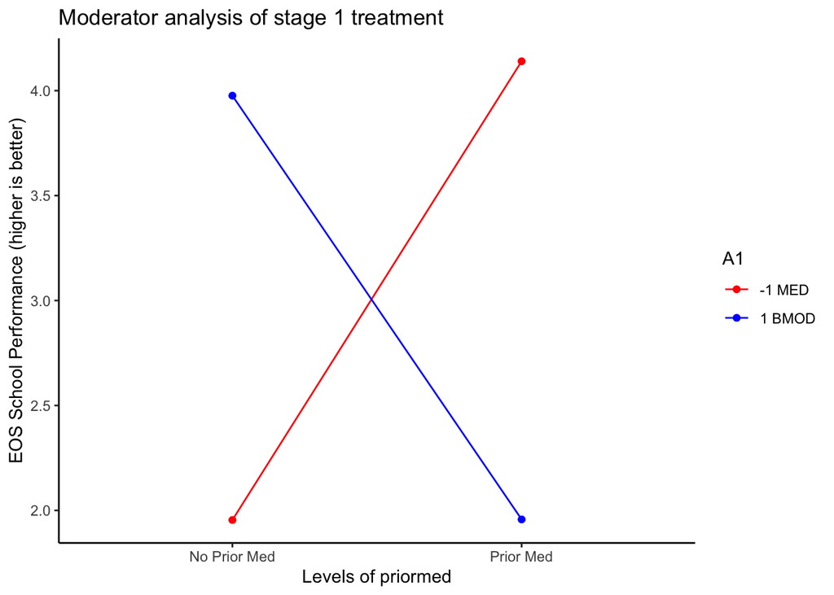

```r
ep1 <- emmeans::emmip(em1, A1 ~ priormed, style = "factor", )
ep1 + theme_classic() + labs(title = "Moderator analysis of stage 1 treatment", y = "EOS School Performance (higher is better)") +
    scale_x_discrete(labels = c("No Prior Med", "Prior Med")) + scale_color_manual("A1",
    values = c(`-1` = "red", `1` = "blue"), labels = c(`-1` = "-1 MED", `1` = "1 BMOD"))
```

### Knowledge check:

1. What is the effect of starting an AI with BMOD (1) vs MED (-1) for those on prior med? Is this effect significant?
2. Do the results of the moderator regressions suggest we can use baseline covariates to tailor first-stage treatment? Why?

## 5 Moderators of stage 2 treatment

Here we fit a **moderated regression model** using the data from non-responders. The goal is to discover if we can use *the initial treatment* `A1` and *adherence to initial treatment* `adherence` to select a tactic for **non-responders**, adjusting for baseline covariates $\mathbf{X}_c$. The model is as follows:

$$\begin{gather*}
E[Y \mid \mathbf{X}_c, A_1, \text{adherence}, A_2, R = 0] = \eta_0 + \eta^T\mathbf{X}_c + \eta_1 A_{1} + \eta_2\text{adherence} + \beta_1 A_2 + \\
\beta_2 (A_2 \times A_1) + \beta_{3} (A_2 \times \text{adherence})
\end{gather*}$$

```r
# Filter to non-responders, then center among non-responders
adhd_nr_c <- adhd %>%
    filter(R == 0) %>%
    mutate(across(.cols = c(odd, severity, priormed, race, NRtime, adherence), ~.x -
        mean(.x, na.rm = TRUE), .names = "{.col}_c"))

mod2 <- geepack::geeglm(Y2 ~ odd_c + severity_c + priormed_c + race_c + A1 * A2 +
    A2 * adherence, id = ID, data = adhd_nr_c)

tidy(mod2) %>%
    knitr::kable(digits = 2)
```

| term | estimate | std.error | statistic | p.value |
| --- | --- | --- | --- | --- |
| (Intercept) | 2.36 | 0.17 | 201.70 | 0.00 |
| odd_c | -0.62 | 0.27 | 5.16 | 0.02 |
| severity_c | -0.05 | 0.07 | 0.53 | 0.47 |
| priormed_c | -0.58 | 0.33 | 2.97 | 0.08 |
| race_c | 0.26 | 0.42 | 0.40 | 0.53 |
| A1 | 0.42 | 0.15 | 7.83 | 0.01 |
| A2 | -1.17 | 0.17 | 49.01 | 0.00 |
| adherence | 0.93 | 0.26 | 13.11 | 0.00 |
| A1:A2 | -0.15 | 0.12 | 1.50 | 0.22 |
| A2:adherence | 1.73 | 0.26 | 46.08 | 0.00 |

Here we find that `adherence` is a significant moderator of stage 2 treatment $A_2$, but $A_1$ is not. Only the second-stage coefficients, $\beta$, are causal. The first-stage coefficients, $\eta$, are non-causal and will be biased as a result of sub-setting to non-responders.

### Marginal means of stage 2

```r
em2 <- emmeans::emmeans(mod2, ~A1 + A2 | adherence, weights = "prop")
print(em2)
```

```
adherence = 0:
 A1 A2 emmean    SE  df asymp.LCL asymp.UCL
 -1 -1  2.956 0.373 Inf     2.225      3.69
  1 -1  4.110 0.282 Inf     3.558      4.66
 -1  1  0.915 0.256 Inf     0.414      1.42
  1  1  1.461 0.305 Inf     0.864      2.06

adherence = 1:
 A1 A2 emmean    SE  df asymp.LCL asymp.UCL
 -1 -1  2.150 0.383 Inf     1.400      2.90
  1 -1  3.304 0.353 Inf     2.613      4.00
 -1  1  3.576 0.327 Inf     2.934      4.22
  1  1  4.121 0.267 Inf     3.597      4.64

Results are averaged over the levels of: odd_c, priormed_c, race_c
Covariance estimate used: vbeta
Confidence level used: 0.95
```

### Interaction plot of stage 2

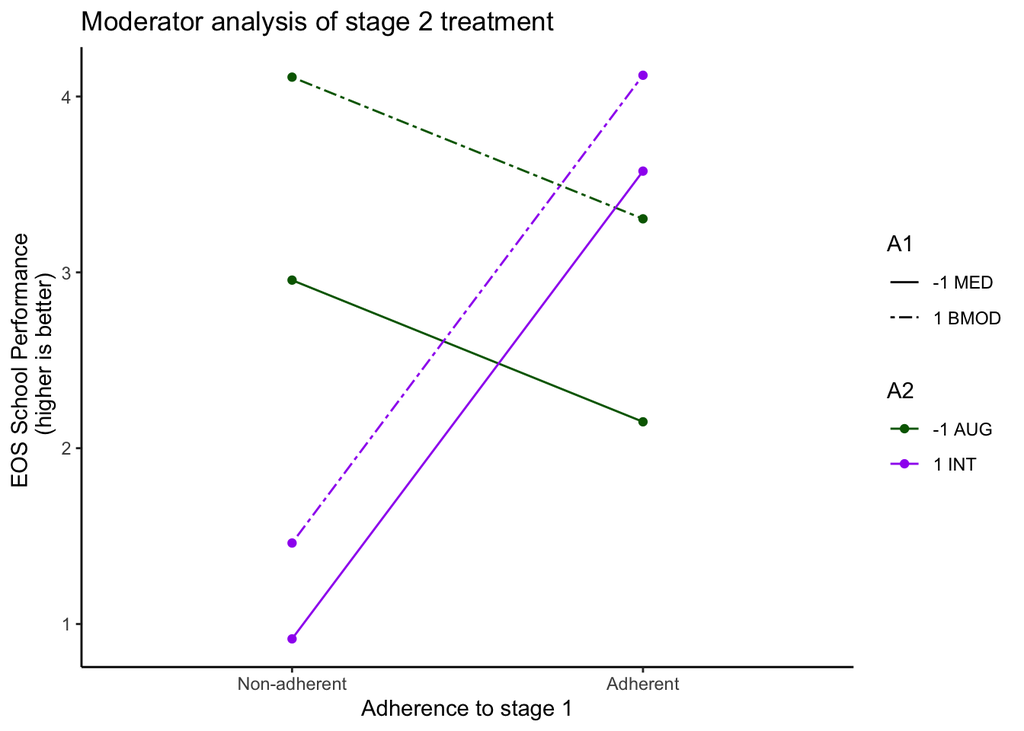

```r
ep2 <- emmeans::emmip(em2, A1 + A2 ~ adherence, style = "factor")

# Prettify plot
ep2$data %>%
    mutate(across(1:3, as.factor)) %>%
    ggplot(aes(xvar, yvar, color = A2, linetype = A1, group = tvar)) + geom_line() +
    geom_point() + scale_color_manual("A2", values = c(`-1` = "darkgreen", `1` = "purple"),
    labels = c(`-1` = "-1 AUG", `1` = "1 INT")) + scale_linetype_manual("A1", values = c(`-1` = 1,
    `1` = 6), labels = c(`-1` = "-1 MED", `1` = "1 BMOD")) + labs(title = "Moderator analysis of stage 2 treatment",
    x = "Adherence to stage 1", y = "EOS School Performance \n (higher is better)") +
    scale_x_discrete(labels = c("Non-adherent", "Adherent")) + theme_classic()
```

### Knowledge check:

1. Why do we subset to non-responders when fitting a second-stage moderated regression?
2. What is the optimal tactic for non-adhering, non-responders to BMOD(1)? MED(-1)?

## 6 Q-learning

We use Q-learning to estimate the effect of a more deeply-tailored AI combining the optimal tactic at each stage. Estimation has three steps:

1. Fit stage 2 moderator regression (`mod2`!) ✅
2. Predict the outcome under the optimal decision rule: $\hat{Y}^{opt}_i$
3. Fit stage 1 moderator regression on $\hat{Y}^{opt}_i$

### Predict optimal outcome

```r
# Predicted outcome under observed treatment A2
Y2_f <- fitted(mod2)[, 1]

# Make counterfactual data.frame
adhd_nr_alt <- adhd_nr_c %>%
    mutate(A2 = -1 * A2)

# Predict outcome under counterfactual treatment a2
Y2_alt <- predict(mod2, newdata = adhd_nr_alt)

# data.frame to store optimal outcome under stage 2 tactic
adhd_nr_opt <- adhd_c %>%
    filter(R == 0)
adhd_nr_opt <- adhd_nr_opt %>%
    mutate(Y2 = pmax(Y2_f, Y2_alt), A2_opt = if_else(Y2_alt > Y2_f, -1 * A2, A2))

# merge non-responders w/ responders
adhd_opt <- bind_rows(adhd_nr_opt, adhd_c %>%
    filter(R == 1))
```

### Fit stage 1 moderated regression controlling for optimal second-stage

Now we fit a model for the first stage on the `adhd.opt` data.frame which controls for the optimal second stage. The moderator of interest is `priormed`.

$$\begin{gather}
E[\hat{Y}^{opt} \mid \mathbf{X}_c, \text{priormed}, A_1] = \beta_0 +
\eta^TX_c + \beta_1\text{priormed} +
\beta_2A_1 + \beta_3(A_1 \times \text{priormed})
\end{gather}$$

```r
Qmod1 <- geepack::geeglm(Y2 ~ odd_c + severity_c + race_c + A1 * priormed, id = ID,
    data = adhd_opt)

tidy(Qmod1) %>%
    knitr::kable(digits = 2)
```

| term | estimate | std.error | statistic | p.value |
| --- | --- | --- | --- | --- |
| (Intercept) | 3.62 | 0.07 | 2599.29 | 0.00 |
| odd_c | -0.57 | 0.13 | 18.27 | 0.00 |
| severity_c | -0.12 | 0.04 | 10.18 | 0.00 |
| race_c | 0.73 | 0.19 | 14.72 | 0.00 |
| A1 | 0.69 | 0.07 | 96.00 | 0.00 |
| priormed | -0.04 | 0.17 | 0.04 | 0.83 |
| A1:priormed | -0.91 | 0.17 | 28.25 | 0.00 |

**Warning**

The standard errors are incorrect due to estimating $\hat{Y}^{opt}$. We need special software (see `qlaci`) to do proper inference.

### Interaction plot of optimal tactic

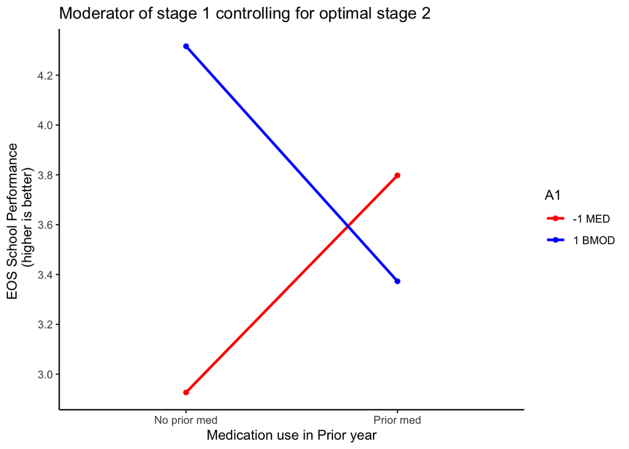

```r
qem1 <- emmeans::emmeans(Qmod1, ~A1 | priormed, weights = "prop")
qep1 <- emmeans::emmip(qem1, A1 ~ priormed, style = "factor")

# Prettify plot
qep1$data %>%
    mutate(across(1:2, as.factor)) %>%
    ggplot(aes(xvar, yvar, color = A1, group = tvar)) + geom_line(linewidth = 1) +
    geom_point() + scale_color_manual("A1", values = c(`-1` = "red", `1` = "blue"),
    labels = c(`-1` = "-1 MED", `1` = "1 BMOD")) + theme_classic() + labs(title = "Moderator of stage 1 controlling for optimal stage 2",
    x = "Medication use in Prior year", y = "EOS School Performance \n (higher is better)") +
    scale_x_discrete(labels = c("No prior med", "Prior med")) + scale_y_continuous(n.breaks = 8)
```

## 7 The `qlaci` package

First, we need to specify the contrast matrix that will be used for the *stage-1 regression* (step 3 of Q-learning). `qlaci()` uses this matrix to estimate the mean outcomes under each of the first-stage treatments (averaging over the future optimal response) at both levels of `priormed`. We also specify a contrast that estimates the mean outcome if everyone in the study had received the optimal more deeply-tailored AI (averaging over levels of `priormed`).

```r
pPM <- mean(adhd_c$priormed)  # probability of priormed

## contrast matrix - we must transpose this for qlaci
c1 <- rbind(`Mean Y under bmod, prior med` = c(1, rep(0, 3), 1, 1, 1), `Mean Y under med, prior med` = c(1,
    rep(0, 3), 1, -1, -1), `Mean diff (bmod-med) for prior med` = c(0, rep(0, 3),
    0, 2, 2), `Mean Y under bmod, no prior med` = c(1, rep(0, 3), 0, 1, 0), `Mean Y under med, no prior med` = c(1,
    rep(0, 3), 0, -1, 0), `Mean diff (bmod-med) for no prior med` = c(0, rep(0, 3),
    0, 2, 0), `Mean Y Optimal AI` = c(1, rep(0, 3), pPM, 1 - 2 * pPM, -pPM))
```

The following are the arguments we need to provide to `qlaci()`:

- `H10`: Baseline covariates we want to adjust for in the first-stage regression.
- `H11`: Variables that interact with first-stage treatment in the first-stage regression (candidate variables for deeper tailoring).
- `A1`: Indicator for first-stage treatment
- `Y1`: A continuous intermediate outcome. Here, we don’t have an intermediate outcome, so we set this to zero for everyone.
- `H20`: A matrix, with each column containing data for a main-effects term in the second-stage regression (analogous to `H10`).
- `H21`: Variables that interact with second-stage treatment `A2` in the second-stage regression (candidate variables for deeper tailoring).
- `A2`: Indicator for second-stage treatment
- `Y2`: End-of-study outcome
- `S`: Indicator for whether an individual was re-randomized (1 = re-randomized; 0 = otherwise)
- `c1`: Contrast matrix for first-stage regression (see above)

```r
attach(adhd_c) # with attach we can be lazy and refer to variables in the data.frame directly

q1 <-  qlaci::qlaci(H10 = cbind(1, odd_c, severity_c, race_c, priormed),
                   H11 = cbind(A1 = 1, "A1:priormed" = priormed),
                   A1 = A1,
                   Y1 = rep(0, nrow(adhd_c)), # set to zero for everyone; we care only about EOS outcome
                   H20 = cbind(1, odd_c, severity_c, race_c,
                               priormed, A1, adherence),
                   H21 = cbind(A2 = 1, "A1:A2" = A1,
                               "A2:adherence" = adherence),
                   A2 = A2,
                   Y2 = Y2,
                   S = 1 - R,
                   c1 = t(c1))

detach(adhd_c)
```

### qlaci results

The the coefficients estimated by `qlaci()` combined with the user specified contrast matrix give us the means under first-stage treatment options for levels of `priormed` with valid confidence intervals.

```r
q1$ci1 %>%
    knitr::kable(digits = 2, caption = "Estimated optimal AI tailoring on prior med and adherence")
```

Estimated optimal AI tailoring on prior med and adherence

|  | est | low | upp |
| --- | --- | --- | --- |
| Mean Y under bmod, prior med | 3.37 | 2.75 | 3.89 |
| Mean Y under med, prior med | 3.80 | 3.23 | 4.40 |
| Mean diff (bmod-med) for prior med | -0.43 | -1.19 | 0.36 |
| Mean Y under bmod, no prior med | 4.32 | 3.88 | 4.66 |
| Mean Y under med, no prior med | 2.93 | 2.52 | 3.33 |
| Mean diff (bmod-med) for no prior med | 1.39 | 0.77 | 1.85 |
| Mean Y Optimal AI | 4.16 | 3.80 | 4.45 |

### Knowledge check:

1. Why do we need to use Q-learning to estimate a more deeply-tailored AI? What is wrong with simply running two moderator regressions?
2. Looking at the above table, what do the two contrasts (bmod - med) for levels of prior med tell us about tailoring?
3. Write the decision rules corresponding to the more deeply-tailored AI.